# Case Study: How does a bike-share navigate speedy success?

Treesa Sabu

2024-05-10

## Introduction

In 2016, Cyclistic launched a successful bike-share offering. Since then, the program has grown to a fleet of 5,824 bicycles that are geotracked and locked into a network of 692 stations across Chicago. The bikes can be unlocked from one station and returned to any other station in the system anytime. Until now, Cyclistic’s marketing strategy relied on building general awareness and appealing to broad consumer segments. One approach that helped make these things possible was the flexibility of its pricing plans: single-ride passes, full-day passes, and annual memberships. Customers who purchase single-ride or full-day passes are referred to as casual riders. Customers who purchase annual memberships are Cyclistic members.

Cyclistic’s finance analysts have concluded that annual members are much more profitable than casual riders. Although the pricing flexibility helps Cyclistic attract more customers, Analysts believes that maximizing the number of annual members will be key to future growth. Rather than creating a marketing campaign that targets all-new customers, Moreno believes there is a solid opportunity to convert casual riders into members. They notes that casual riders are already aware of the Cyclistic program and have chosen Cyclistic for their mobility needs.

## Problems

Design marketing strategies aimed at converting casual riders into annual members.In order to do that, however, the team needs to better understand how annual members and casual riders differ, why casual riders would buy a membership, and how digital media could affect their marketing tactics.

- How do annual members and casual riders use Cyclistic bikes differently?

This is what we are planning to find the answer from this case study.

## Solutions

The data for the analysis is downloaded from https://divvy-tripdata.s3.amazonaws.com/index.html. Last 12 month data (2023 May to 2024 April) is used for the analysis.

```r
library(dplyr)
library(tidyverse)
library(skimr)
library(janitor)
```

```r
library(readr)
library(ggplot2)
```

```r
df <- list.files(path="E:/MBA/Cousera/Assignments/data analytics/bike/csv", full.names = TRUE) %>% lapply(read_csv) %>% bind_rows
#dropping all not available values rows
cleaned_data <- df %>% drop_na()
head(cleaned_data)
```

```
## # A tibble: 6 × 13
##   ride_id          rideable_type started_at          ended_at
##   <chr>            <chr>         <dttm>              <dttm>
## 1 DDEB93BC2CE9AA77 classic_bike  2023-05-10 16:47:01 2023-05-10 16:59:52
## 2 C07B70172FC92F59 classic_bike  2023-05-09 18:30:34 2023-05-09 18:39:28
## 3 2BA66385DF8F815A classic_bike  2023-05-30 15:01:21 2023-05-30 15:17:00
## 4 31EFCCB05F12D8EF docked_bike   2023-05-09 14:13:40 2023-05-09 14:47:20
## 5 71DFF834E1D3CE0B classic_bike  2023-05-06 16:47:22 2023-05-06 16:52:13
## 6 2117485899B4CEA4 classic_bike  2023-05-15 12:47:26 2023-05-15 13:00:05
## # ℹ 9 more variables: start_station_name <chr>, start_station_id <chr>,
## #   end_station_name <chr>, end_station_id <chr>, start_lat <dbl>,
## #   start_lng <dbl>, end_lat <dbl>, end_lng <dbl>, member_casual <chr>
```

```r
str(cleaned_data)
```

```
## tibble [4,335,839 × 13] (S3: tbl_df/tbl/data.frame)
##  $ ride_id           : chr [1:4335839] "DDEB93BC2CE9AA77" "C07B70172FC92F59" "2BA66385DF8F815A" "31EFCCB05F12D8EF" ...
##  $ rideable_type     : chr [1:4335839] "classic_bike" "classic_bike" "classic_bike" "docked_bike" ...
##  $ started_at        : POSIXct[1:4335839], format: "2023-05-10 16:47:01" "2023-05-09 18:30:34" ...
##  $ ended_at          : POSIXct[1:4335839], format: "2023-05-10 16:59:52" "2023-05-09 18:39:28" ...
##  $ start_station_name: chr [1:4335839] "Carpenter St & Huron St" "Southport Ave & Clark St" "Clinton St & Madison St" "DuSable Lake Shore Dr & Monroe St" ...
##  $ start_station_id  : chr [1:4335839] "13196" "TA1308000047" "TA1305000032" "13300" ...
##  $ end_station_name  : chr [1:4335839] "Damen Ave & Cortland St" "Southport Ave & Belmont Ave" "McClurg Ct & Ohio St" "Adler Planetarium" ...
##  $ end_station_id    : chr [1:4335839] "13133" "13229" "TA1306000029" "13431" ...
##  $ start_lat         : num [1:4335839] 41.9 42 41.9 41.9 41.8 ...
##  $ start_lng         : num [1:4335839] -87.7 -87.7 -87.6 -87.6 -87.6 ...
##  $ end_lat           : num [1:4335839] 41.9 41.9 41.9 41.9 41.8 ...
##  $ end_lng           : num [1:4335839] -87.7 -87.7 -87.6 -87.6 -87.6 ...
##  $ member_casual     : chr [1:4335839] "member" "member" "member" "casual" ...
```

```r
glimpse(cleaned_data)
```

```
## Rows: 4,335,839
## Columns: 13
## $ ride_id            <chr> "DDEB93BC2CE9AA77", "C07B70172FC92F59", "2BA66385DF…
## $ rideable_type      <chr> "classic_bike", "classic_bike", "classic_bike", "do…
## $ started_at         <dttm> 2023-05-10 16:47:01, 2023-05-09 18:30:34, 2023-05-…
## $ ended_at           <dttm> 2023-05-10 16:59:52, 2023-05-09 18:39:28, 2023-05-…
## $ start_station_name <chr> "Carpenter St & Huron St", "Southport Ave & Clark S…
## $ start_station_id   <chr> "13196", "TA1308000047", "TA1305000032", "13300", "…
## $ end_station_name   <chr> "Damen Ave & Cortland St", "Southport Ave & Belmont…
## $ end_station_id     <chr> "13133", "13229", "TA1306000029", "13431", "KA15030…
## $ start_lat          <dbl> 41.89456, 41.95708, 41.88275, 41.88096, 41.79521, 4…
## $ start_lng          <dbl> -87.65345, -87.66420, -87.64119, -87.61674, -87.580…
## $ end_lat            <dbl> 41.91598, 41.93948, 41.89259, 41.86610, 41.78794, 4…
## $ end_lng            <dbl> -87.67733, -87.66375, -87.61729, -87.60727, -87.588…
## $ member_casual      <chr> "member", "member", "member", "casual", "member", "…
```

finding the summary of total share of casual and member riders

```r
total_summary <- cleaned_data %>% group_by(member_casual) %>% summarise(totalCount =n(), .groups = 'drop')
total_summary
```

```
## # A tibble: 2 × 2
##   member_casual totalCount
##   <chr>              <int>
## 1 casual           1524678
## 2 member           2811161
```

finding top and bottom starting stations for casual riders

```r
filter_casual <- cleaned_data %>% filter(member_casual=='casual')
summary_casual <- filter_casual %>% group_by(start_station_name) %>% summarise(totalCount =n(), .groups = 'drop')
arrange_casual = as.data.frame(summary_casual)
arrange_casual = arrange_casual %>% arrange(-totalCount)
top_10_casual = head(arrange_casual, 10)
bottom_10_casual = tail(arrange_casual, 10)
top_10_casual
```

```
##                    start_station_name totalCount
## 1             Streeter Dr & Grand Ave      44371
## 2   DuSable Lake Shore Dr & Monroe St      29566
## 3               Michigan Ave & Oak St      21390
## 4  DuSable Lake Shore Dr & North Blvd      19140
## 5                     Millennium Park      18948
## 6                      Shedd Aquarium      17535
## 7                 Theater on the Lake      15214
## 8                      Dusable Harbor      15172
## 9                   Adler Planetarium      11823
## 10                    Montrose Harbor      11165
```

```r
bottom_10_casual
```

```
##                               start_station_name totalCount
## 1496         Public Rack - Walden Pkwy & 99th St          1
## 1497       Public Rack - Washtenaw Ave & 63rd St          1
## 1498      Public Rack - Wentworth Ave & 103rd St          1
## 1499                Public Rack - Western & 74th          1
## 1500 Public Rack - Western Ave & 106th St - West          1
## 1501   Public Rack - Western Ave & 111th St - NW          1
## 1502        Public Rack - Western Blvd & 53rd St          1
## 1503          Public Rack - Whipple St & 63rd St          1
## 1504                        Spaulding Ave & 16th          1
## 1505               Wellington Ave & Mulligan Ave          1
```

finding top and bottom starting stations for member riders

```r
filter_member <- cleaned_data %>% filter(member_casual=='member')
summary_member <- filter_member %>% group_by(start_station_name) %>% summarise(totalCount =n(), .groups = 'drop')
arrange_member = as.data.frame(summary_member)
arrange_member = arrange_member %>% arrange(-totalCount)
top_10_member = head(arrange_member, 10)
bottom_10_member = tail(arrange_member, 10)
top_10_member
```

```
##              start_station_name totalCount
## 1  Clinton St & Washington Blvd      25433
## 2      Kingsbury St & Kinzie St      24561
## 3             Clark St & Elm St      22821
## 4       Clinton St & Madison St      20503
## 5         Wells St & Concord Ln      18935
## 6             Wells St & Elm St      18680
## 7      University Ave & 57th St      17664
## 8     Clinton St & Jackson Blvd      16624
## 9          Broadway & Barry Ave      16522
## 10     Loomis St & Lexington St      16506
```

```r
bottom_10_member
```

```
##                             start_station_name totalCount
## 1440 Public Rack - Wilbur Wright College North          1
## 1441                     Rockwell St & 63rd St          1
## 1442               S Michigan Ave & E 118th St          1
## 1443               Sacramento Ave & Pratt Blvd          1
## 1444                       St. Louis & 71st St          1
## 1445                       State St & 123rd St          1
## 1446                  W 103rd St & S Avers Ave          1
## 1447                  Wentworth Ave & 104th St          1
## 1448                         Wood St & 84th St          1
## 1449                          Woodlawn & 103rd          1
```

finding top and bottom end stations for casual riders

```r
filter_casual <- cleaned_data %>% filter(member_casual=='casual')
summary_casual <- filter_casual %>% group_by(end_station_name) %>% summarise(totalCount =n(), .groups = 'drop')
arrange_casual = as.data.frame(summary_casual)
arrange_casual = arrange_casual %>% arrange(-totalCount)
top_10_casual = head(arrange_casual, 10)
bottom_10_casual = tail(arrange_casual, 10)
top_10_casual
```

```
##                      end_station_name totalCount
## 1             Streeter Dr & Grand Ave      48492
## 2   DuSable Lake Shore Dr & Monroe St      27521
## 3               Michigan Ave & Oak St      22644
## 4  DuSable Lake Shore Dr & North Blvd      22593
## 5                     Millennium Park      21307
## 6                 Theater on the Lake      16803
## 7                      Shedd Aquarium      15895
## 8                      Dusable Harbor      13486
## 9                     Montrose Harbor      11084
## 10             Clark St & Lincoln Ave      10630
```

```r
bottom_10_casual
```

```
##                               end_station_name totalCount
## 1515     Public Rack - Vincennes Ave & 91st St          1
## 1516     Public Rack - Washtenaw Ave & 63rd St          1
## 1517              Public Rack - Western & 74th          1
## 1518    Public Rack - Western Ave & Jarvis Ave          1
## 1519      Public Rack - Western Blvd & 52nd St          1
## 1520 Public Rack - Wilbur Wright College North          1
## 1521        Public Rack - Yates Ave & 100th St          1
## 1522                      Pulaski Rd & 68th St          1
## 1523                      Spaulding Ave & 16th          1
## 1524             Wellington Ave & Mulligan Ave          1
```

finding top and bottom end stations for member riders

```r
filter_member <- cleaned_data %>% filter(member_casual=='member')
summary_member <- filter_member %>% group_by(end_station_name) %>% summarise(totalCount =n(), .groups = 'drop')
arrange_member = as.data.frame(summary_member)
arrange_member = arrange_member %>% arrange(-totalCount)
top_10_member = head(arrange_member, 10)
bottom_10_member = tail(arrange_member, 10)
top_10_member
```

```
##                end_station_name totalCount
## 1  Clinton St & Washington Blvd      26244
## 2      Kingsbury St & Kinzie St      24677
## 3             Clark St & Elm St      22801
## 4       Clinton St & Madison St      21717
## 5         Wells St & Concord Ln      19656
## 6             Wells St & Elm St      18698
## 7      University Ave & 57th St      17960
## 8          Broadway & Barry Ave      17079
## 9           Canal St & Adams St      16779
## 10    Clinton St & Jackson Blvd      16579
```

```r
bottom_10_member
```

```
##                               end_station_name totalCount
## 1439       Public Rack - Western Ave & 79th St          1
## 1440      Public Rack - Western Blvd & 53rd St          1
## 1441 Public Rack - Wilbur Wright College North          1
## 1442   Public Rack - Yates Blvd & Exchange Ave          1
## 1443              Public Rack - Zapata Academy          1
## 1444               Sacramento Ave & Pratt Blvd          1
## 1445                       St. Louis & 71st St          1
## 1446                   Torrence Ave & 126th Pl          1
## 1447                         Wood St & 84th St          1
## 1448                          Woodlawn & 103rd          1
```

The below code snippet will plot the rideable type v/s number for each type member of casual.

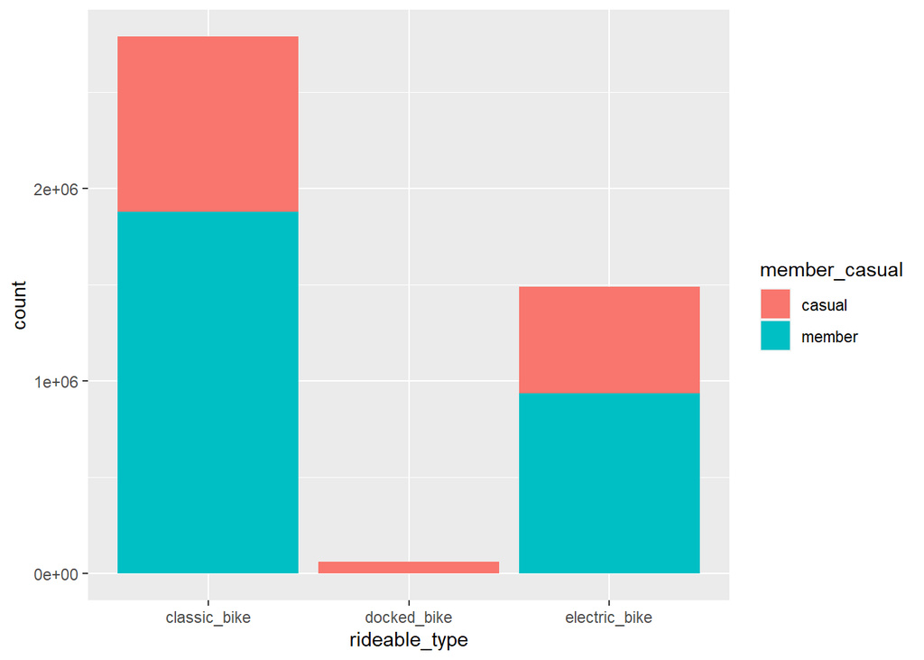

```r
plot_biketype_and_member <- ggplot(data=cleaned_data) + geom_bar(mapping = aes(x=rideable_type, fill=member_casual))
plot_biketype_and_member
```

The below code snippet will plot the start station v/s number for each type member of casual.

[figure not shown]

```r
plot_start_and_member <- ggplot(data=cleaned_data) + geom_bar(mapping = aes(x=start_station_name, fill=member_casual))
plot_start_and_member
```

[figure not shown]

```r
plot_end_and_member <- ggplot(data=cleaned_data) + geom_bar(mapping = aes(x=end_station_name, fill=member_casual))
plot_start_and_member
```

## Conclusion

- A total of 4335839 observations were subject for study after cleaning the data.
- 1524678 were casual riders and 2811161 were member riders.
- classic bikes and electric bikes were mostly used by member riders. only half this used by casual riders but in the case of docked bikes it was exclusevely used by casual riders.
- Streeter Dr & Grand Ave is the main starting and ending station of casual riders.
- Clinton St & Washington Blvd is the main starting and ending station of member riders.

## Next Steps

- Can provide better plans for docked bikes will attract more casual riders to member riders.
- Can have better marketing strategy implement in stations like Streeter Dr & Grand Ave.